# polyRAD Tutorial

Lindsay V. Clark, University of Illinois, Urbana-Champaign

02 October 2022

## Introduction

polyRAD is an R package that assists with genotype calling from DNA sequence datasets such as genotyping-by-sequencing (GBS) or restriction site-associated DNA sequencing (RAD) in polyploids and diploids. Genotype likelihoods are estimated from allelic read depth, genotype prior probabilities are estimated from population parameters, and then genotype posterior probabilities are estimated from likelihoods and prior probabilities. Posterior probabilities can be used directly in downstream analysis, converted to posterior mean genotypes for analyses of additive genetic effects, or used for export of the most probable genotypes for analyses that require discrete genotypic data.

Analyses in polyRAD center around objects of an S3 class called `RADdata`. A single `RADdata` object contains the entire dataset of read depth and locus information, as well as parameters that are estimated during the course of analysis.

## Summary of available functions

For any function named in this section, see its help page for more information. (For example by typing `?VCF2RADdata` into the R console.)

Several functions are available for import of read depth data and (optionally) alignment information into a RADdata object:

- `VCF2RADdata`
- `readTagDigger`
- `readStacks`
- `readHMC`
- `readTASSELGBSv2`
- `readProcessSamMulti`
- `readProcessIsoloci`
- `readDArTag`

More generally, the `RADdata` function is used for constructing RADdata objects; see the help page for that function for more information on what data are needed.

Several pipelines are available for genotype estimation, depending on how the population is structured (i.e. what the genotype prior probabilities should be):

- `PipelineMapping2Parents`
- `IterateHWE`
- `IterateHWE_LD`
- `IteratePopStruct`
- `IteratePopStructLD`

For exporting the estimated genotypes to other software:

- `ExportGAPIT`
- `Export_rrBLUP_Amat`
- `Export_rrBLUP_GWAS`
- `Export_TASSEL_Numeric`
- `Export_polymapR`
- `Export_polymapR_probs`
- `Export_MAPpoly`
- `Export_GWASpoly`
- `Export_Structure`
- `Export_adegenet_genind`
- `RADdata2VCF`

If you need continuous numerical genotypes exported in some other format, see `GetWeightedMeanGenotypes`. If you need discrete numerical genotypes, see `GetProbableGenotypes`. Also, `GetLikelyGen` returns the most likely genotypes (based on read depth only) for a single sample.

There are also various utilities for manipulating RADdata objects:

- `SubsetByTaxon`
- `SubsetByLocus`
- `SubsetByPloidy`
- `SplitByChromosome`
- `MergeRareHaplotypes`
- `MergeTaxaDepth`
- `RemoveMonomorphicLoci`
- `RemoveHighDepthLoci`
- `RemoveUngenotypedLoci`
- `EstimateContaminationRate`
- `StripDown`
- `LocusInfo`

For identifying problematic loci and individuals:

- `HindHe`
- `HindHeMapping`
- `ExpectedHindHe`
- `ExpectedHindHeMapping`
- `InbreedingFromHindHe`

For interrogating the genotype calling process, see `?ExamineGenotype`.

See `?GetTaxa` for a list of accessor functions as well.

## Considerations for genome biology

Ploidy is represented in two dimensions in RADdata objects. The first dimension, indicating inheritance mode of loci with respect to the reference genome, is specified in the `possiblePloidies` slot. The second dimension, indicating additional genome duplication within individuals, is specified by the `taxaPloidy` slot. The product of `possiblePloidies` and `taxaPloidy`, divided by two, indicates the possible inheritance modes within each individual.

If you expect each locus to align to a unique location within the reference genome, set `possiblePloidies = list(2)`. If you are working, for example, with an allotetraploid but are aligning to the genome of one diploid ancestor, set `possiblePloidies = list(c(2, 2))` to indicate that a single alignment location will represent two Mendelian loci. For example, if you are analysing allohexaploid winter wheat, if you are aligning to the allohexaploid reference you would set `possiblePloidies = list(2)`, but if you were aligning to the reference of a diploid ancestor you would set `possiblePloidies = list(c(2, 2, 2))`. In reality, the data may be messier than that, particularly if you are using a reference-free variant calling pipeline, and so you can for example set `possiblePloidies = list(2, c(2, 2), c(2, 2, 2))` to test each genomic location for whether it seems to consist of one, two, or three Mendelian loci. Another example case is an ancient tetraploid genome in which some regions have diploidized and others still segregate in an autotetraploid fashion, which could be coded as `possiblePloidies = list(2, 4)` or `possiblePloidies = list(2, 4, c(2, 2))`. Keep in mind that the memory footprint of polyRAD during and after genotyping will scale linearly with the number of inheritance modes tested, however.

One situation you want to avoid is alleles from a single Mendelian locus aligning to multiple locations in the reference, as polyRAD will treat these as different loci. The reference genome used in variant calling should therefore be one in which none of the chromosomes are expected to pair with each other at meiosis. If you are studying a mixture of two species and their hybrids, I recommend performing variant calling and allelic read depth quantification against the reference genome of just one species (whichever has a better assembly and annotation available), then taking the set of RAD tags in which variants were called and aligning them to the reference genome of the other species, and filtering to retain only markers with alignment locations in both species.

The `taxaPloidy` slot is a multiplier on top of the `possiblePloidies` slot. It has one value per individual (taxon) in the dataset, but when a RADdata object is created it is possible to just supply one value to assign all individuals the same `taxaPloidy`. For example, if you are studying autotetraploids, you can set `possiblePloidies = list(2)` and `taxaPloidy = 4`, although `possiblePloidies = list(4)` and `taxaPloidy = 2` will also work. An allotetraploid with a diploid reference would be `possiblePloidies = list(c(2,2))` and `taxaPloidy = 2`, and an allotetraploid with an allotetraploid reference would be `possiblePloidies = list(2)` and `taxaPloidy = 2`. If you have, for example, a mixture if diploids, triploids, and tetraploids, you should construct a named integer vector, where the values are the ploidies of the individuals, and the names are the sample names, then pass this vector to the `taxaPloidy` argument when making your RADdata object (see example in “Estimating genotype probabilities in a diversity panel” below). For mapping populations, it is possible for the parents to have different ploidies as long as all progeny are the ploidy expected from the cross (*e.g.* diploid x tetraploid = triploid).

## Estimating genotype probabilities in a mapping population

### Data import example with UNEAK

In this example, we’ll import some data from an F1 mapping population of *Miscanthus sinensis* that were output by the [UNEAK](https://doi.org/10.1371/journal.pgen.1003215) pipeline. These data are from a study by Liu *et al.* (2015; [doi:10.1111/gcbb.12275](https://doi.org/10.1111/gcbb.12275); data available at http://hdl.handle.net/2142/79522), and can be found in the “extdata” folder of the polyRAD installation. *Miscanthus* is an ancient tetraploid that has undergone diploidization. Given the ability of the UNEAK pipeline to filter paralogs, we expect most loci to behave in a diploid fashion, but some may behave in an allotetraploid fashion.

We’ll start by loading polyRAD and importing the data into a `RADdata` object. The `possiblePloidies` argument indicates the expected inheritance modes: diploid (2) and allotetraploid (2 2). The `taxaPloidy` argument indicates that there is no further genome duplication beyond that indicated with `possiblePloidies`.

With your own dataset, you will not need to use `system.file`. Instead, directly create a text string indicating the name of your file (and its location if it is not in the working directory.)

```r
library(polyRAD)
maphmcfile <- system.file("extdata", "ClareMap_HapMap.hmc.txt",
                          package = "polyRAD")
maphmcfile
```

```
## [1] "D:/Program Files/R-4.2.1/library/polyRAD/extdata/ClareMap_HapMap.hmc.txt"
```

```r
mydata <- readHMC(maphmcfile,
                  possiblePloidies = list(2, c(2, 2)),
                  taxaPloidy = 2)
mydata
```

```
## ## RADdata object ##
## 299 taxa and 50 loci
## 766014 total reads
## Assumed sample cross-contamination rate of 0.001
##
## Possible ploidies:
## Autodiploid (2)
## Allotetraploid (2 2)
```

We can view the imported taxa names (subsetted here for space).

```r
GetTaxa(mydata)[c(1:10,293:299)]
```

```
##  [1] "IGR-2011-001"    "Kaskade-Justin"  "Map1-001"        "Map1-002"        "Map1-003"        "Map1-005"        "Map1-008"        "Map1-011"
##  [9] "Map1-016"        "Map1-018"        "Map1-488"        "Map1-489"        "Map1-490"        "Map1-491"        "Zebrinus-Justin" "p196-150A-c"
## [17] "p877-348-b"
```

All names starting with “Map” are progeny. “Kaskade-Justin” and “Zebrinus-Justin” are the parents. “IGR-2011-001”, “p196-150A-c”, and “p877-348-b” aren’t part of the population, but were doubled haploid lines that were used to screen for paralogous markers. We can tell polyRAD which taxa are the parents; since this is an F1 population it doesn’t matter which is “donor” and which is “recurrent”.

```r
mydata <- SetDonorParent(mydata, "Kaskade-Justin")
mydata <- SetRecurrentParent(mydata, "Zebrinus-Justin")
```

Although we will end up excluding the doubled haploid lines from analysis below, if we did want to retain them in the analysis and treat them as haploid for the purpose of genotyping, we could adjust `taxaPloidy` for just these samples:

```r
mydata$taxaPloidy[c("IGR-2011-001", "p196-150A-c", "p877-348-b")] <- 1L
mydata
```

```
## ## RADdata object ##
## 299 taxa and 50 loci
## 766014 total reads
## Assumed sample cross-contamination rate of 0.001
##
## Possible ploidies:
## Autohaploid (1)
## Autodiploid (2)
## Allodiploid (1 1)
## Allotetraploid (2 2)
```

The next thing we’ll want to do is add our genomic alignment data. For this dataset, we have alignment data stored in a CSV file, also in the “extdata” directory of the polyRAD installation. We’ll add it to the `locTable` slot of our `RADdata` object. Be sure to name the new columns “Chr” and “Pos”.

```r
alignfile <- system.file("extdata", "ClareMap_alignments.csv",
                         package = "polyRAD")

aligndata <- read.csv(alignfile, row.names = 1)
head(aligndata)
```

```
##         Sorghum.LG Position.on.Sorghum.LG..bp.
## TP5489           1                     4560204
## TP13305          1                     4584260
## TP18261          1                     2911329
## TP18674          1                      387849
## TP19030          1                     7576879
## TP26698          1                     6972841
```

```r
mydata$locTable$Chr <- aligndata[GetLoci(mydata), 1]
mydata$locTable$Pos <- aligndata[GetLoci(mydata), 2]
head(mydata$locTable)
```

```
##         Chr     Pos
## TP5489    1 4560204
## TP13305   1 4584260
## TP18261   1 2911329
## TP18674   1  387849
## TP19030   1 7576879
## TP26698   1 6972841
```

If you don’t have alignment data in your own dataset, you can still use the pipeline described here. Just set `useLinkage = FALSE` in the code below. The advantage of including alignment data is that gentoypes at linked markers are used for imputing missing or correcting erroneous genotypes.

### Quality control and genotype calling

It is important that the only individuals included in the analysis are those that are truly part of the population. Allele frequencies are used for inferring segregation pattern, and could be incorrect if many individuals are included that are not part of the population. Additionally, the genotype priors will be incorrect for individuals that are not part of the population, leading to incorrect genotypes.

At this point we would normally do

```r
mydata <- AddPCA(mydata)
```

However, because a very small number of markers was used in this example dataset, the PCA does not accurately reflect the relatedness of individuals. Here I will load a PCA that was done with the full set of markers.

```r
load(system.file("extdata", "examplePCA.RData", package = "polyRAD"))
mydata$PCA <- examplePCA
```

Now a plot can be used for visualizing the relationship among taxa.

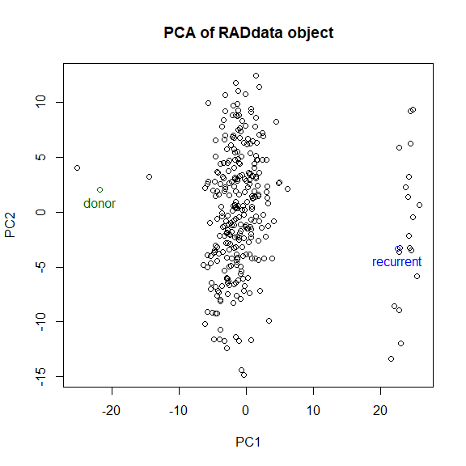

```r
plot(mydata)
```

Now we’ll extract a subset of taxa that we actually want to analyze. We can see from the plot that a fair number of them were the product of self-fertilization of “Zebrinus-Justin” and should be eliminated.

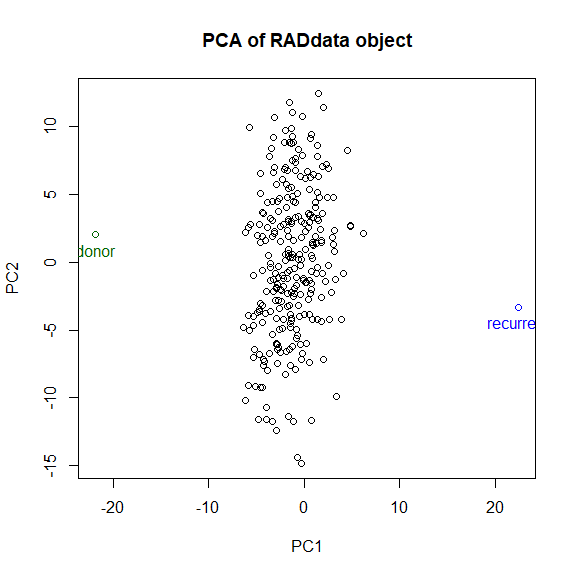

```r
realprogeny <- GetTaxa(mydata)[mydata$PCA[,"PC1"] > -10 &
                                 mydata$PCA[,"PC1"] < 10]
# eliminate the one doubled haploid line in this group
realprogeny <- realprogeny[!realprogeny %in% c("IGR-2011-001", "p196-150A-c",
                                               "p877-348-b")]
# also retain parents
keeptaxa <- c(realprogeny, GetDonorParent(mydata), GetRecurrentParent(mydata))

mydata <- SubsetByTaxon(mydata, taxa = keeptaxa)
plot(mydata)
```

Now we can perform a preliminary run of the pipeline. The `allowedDeviation` argument indicates how different the apparent allele frequency (based on read depth ratios) can be from an expected allele frequency (determined based on ploidy and mapping population type) and still be classified as that allele frequency. The default settings assume an F1 population, but the population type can be adjusted using the `n.gen.backcrossing`, `n.gen.intermating`, and `n.gen.selfing` arguments. We’ll also lower `minLikelihoodRatio` from the default because one of the parents has many uncertain genotypes under the tetraploid model (which was determined by exploration of the dataset outside of this tutorial; many NA values were observed in `priorProb` under the default). Since this first run is for a rough estimate of genotypes, we’ll set `useLinkage = FALSE` to save a little computational time.

```r
mydata2 <- PipelineMapping2Parents(mydata,
                                   freqAllowedDeviation = 0.06,
                                   useLinkage = FALSE,
                                   minLikelihoodRatio = 2)
```

```
## Making initial parameter estimates...
```

```
## Generating sampling permutations for allele depth.
```

```
## Done.
```

We can use these preliminary estimates to determine whether we need to adjust the overdispersion parameter. Exactly how much does read depth distribution deviate from what would be expected under binomial distibution? The `TestOverdispersion` function will help us here.

```r
overdispersionP <- TestOverdispersion(mydata2, to_test = 8:15)
```

```
## Optimal value is 12.
```

```r
sapply(overdispersionP[names(overdispersionP) != "optimal"],
       quantile, probs = c(0.01, 0.25, 0.5, 0.75, 0.99))
```

```
##               8           9          10          11          12           13           14           15
## 1%  0.005533597 0.004096143 0.002848244 0.001954561 0.001322713 0.0009932275 0.0007527206 0.0005746429
## 25% 0.304361182 0.279742132 0.258070046 0.239189269 0.223981900 0.2093677395 0.1957778953 0.1837745108
## 50% 0.583948430 0.562335702 0.545448898 0.528202715 0.512373571 0.4977739384 0.4842515536 0.4706852334
## 75% 0.818619207 0.808643509 0.799476463 0.793000540 0.785103002 0.7775481475 0.7704398101 0.7645633921
## 99% 1.000000000 1.000000000 1.000000000 1.000000000 1.000000000 1.0000000000 1.0000000000 1.0000000000
```

It looks like `12` follows the expected distribution of p-values most closely, both from the automated output of `TestOverdispersion` and from examining the quantiles of p-values. In the matrix of quantiles, we are looking for columns where the 25th percentile is about 0.25, the 50th percentile is about 0.5, etc. These libraries were made with 15 PCR cycles. If you used more PCR cycles you are likely to have a lower optimal value for the overdispersion parameter, or conversely if you used fewer PCR cycles you will probably have a higher value for the overdispersion parameter.

```r
my_ovdisp <- overdispersionP$optimal
```

Next we can check for markers that are behaving in a non-Mendelian fashion. If we are expecting diploid segregation, all markers should show a $H_{ind}/H_E$ value of 0.5 or less. (For an autopolyploid, the expected value is $\frac{ploidy - 1}{ploidy}$.)

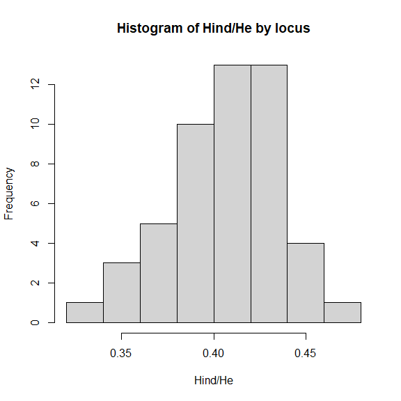

```r
myhindhe <- HindHeMapping(mydata, ploidy = 2L)
hist(colMeans(myhindhe, na.rm = TRUE), col = "lightgrey",
     xlab = "Hind/He", main = "Histogram of Hind/He by locus")
```

How does this compare to the distribution that we might expect from this dataset if all loci were Mendelian? We will use `ExpectedHindHeMapping` with the overdispersion parameter that we estimated above. One your own dataset, I recommend using the default value of `reps`.

```r
set.seed(720)
ExpectedHindHeMapping(mydata, ploidy = 2, overdispersion = my_ovdisp, reps = 2,
                      contamRate = 0.001, errorRate = 0.001)
```

```
## Generating sampling permutations for allele depth.
```

```
## Simulating rep 1
```

```
## Completed 2 simulation reps.
```

```
## Mean Hind/He: 0.468
## Standard deviation: 0.027
## 95% of observations are between 0.426 and 0.529
```

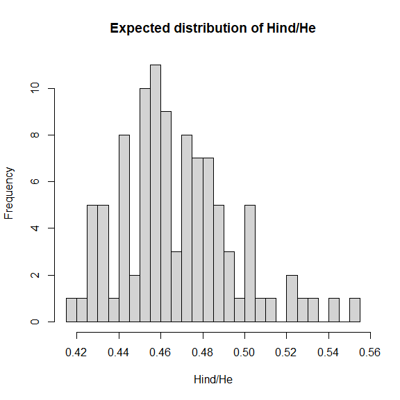

Comparing the observed distribution to the expected distribution, we may want to filter some markers.

```r
goodMarkers <- colnames(myhindhe)[which(colMeans(myhindhe, na.rm = TRUE) < 0.53 &
                                          colMeans(myhindhe, na.rm = TRUE) > 0.43)]
mydata <- SubsetByLocus(mydata, goodMarkers)
```

Now we can re-run the pipeline to properly call the genotypes.

```r
mydata <- PipelineMapping2Parents(mydata,
                                  freqAllowedDeviation = 0.06,
                                  useLinkage = TRUE, overdispersion = my_ovdisp,
                                  minLikelihoodRatio = 2)
```

```
## Making initial parameter estimates...
```

```
## Generating sampling permutations for allele depth.
```

```
## Updating priors using linkage...
```

```
## Done.
```

### Examining the output

We can examine the allele frequencies. Allele frequencies that fall outside of the expected ranges will be recorded as they were estimated from read depth. In this case most are within the expected ranges.

```r
table(mydata$alleleFreq)
```

```
##
## 0.25  0.5 0.75
##   11    2   11
```

Genotype likelihood is also stored in the object for each possible genotype at each locus, taxon, and ploidy. This is the probability of seeing the observed distribution of reads.

```r
mydata$alleleDepth["Map1-089",1:8]
```

```
## TP19030_0 TP19030_1 TP28986_0 TP28986_1 TP31810_0 TP31810_1 TP34939_0 TP34939_1
##         2        13         0         6         0        16         8         9
```

```r
mydata$genotypeLikelihood[[1,"2"]][,"Map1-089",1:8]
```

```
##      TP19030_0    TP19030_1    TP28986_0    TP28986_1    TP31810_0    TP31810_1    TP34939_0    TP34939_1
## 0 9.706321e-04 4.742367e-09 9.987416e-01 1.237115e-07 9.973885e-01 4.444851e-11 8.959640e-06 1.180948e-06
## 1 2.328815e-02 2.328815e-02 3.741288e-02 3.741288e-02 1.567148e-03 1.567148e-03 1.199589e-01 1.199589e-01
## 2 4.742367e-09 9.706321e-04 1.237115e-07 9.987416e-01 4.444851e-11 9.973885e-01 1.180948e-06 8.959640e-06
```

```r
mydata$genotypeLikelihood[[2,"2"]][,"Map1-089",1:8]
```

```
##      TP19030_0    TP19030_1    TP28986_0    TP28986_1    TP31810_0    TP31810_1    TP34939_0    TP34939_1
## 0 9.706321e-04 4.742367e-09 9.987416e-01 1.237115e-07 9.973885e-01 4.444851e-11 8.959640e-06 1.180948e-06
## 1 1.578635e-01 6.145133e-04 2.426471e-01 2.279025e-03 5.641026e-02 1.187627e-05 5.115888e-02 3.296284e-02
## 2 2.328815e-02 2.328815e-02 3.741288e-02 3.741288e-02 1.567148e-03 1.567148e-03 1.199589e-01 1.199589e-01
## 3 6.145133e-04 1.578635e-01 2.279025e-03 2.426471e-01 1.187627e-05 5.641026e-02 3.296284e-02 5.115888e-02
## 4 4.742367e-09 9.706321e-04 1.237115e-07 9.987416e-01 4.444851e-11 9.973885e-01 1.180948e-06 8.959640e-06
```

Above, for one individal (Map1-089), we see its read depth at eight alleles (four loci), followed by the genotype likelihoods under diploid and tetraploid models. For example, at locus TP19030, heterozygosity is the most likely state, although there is a chance that this individual is homozygous for allele 1 and the two reads of allele 0 were due to contamination. If this locus is allotetraploid, it is most likely that there is one copy of allele 0 and three copies of allele 1. Other individuals have higher depth and as a result there is less uncertainty in the genotype, particularly for the diploid model.

The prior genotype probabilities (expected genotype distributions) are also stored in the object for each possible ploidy. These distributions are estimated based on the most likely parent genotypes. Low confidence parent genotypes can be ignored by increasing the `minLikelihoodRatio` argument to `PipelineMapping2Parents`.

```r
mydata$priorProb[[1,"2"]][,1:8]
```

```
##   TP19030_0 TP19030_1 TP28986_0 TP28986_1 TP31810_0 TP31810_1 TP34939_0 TP34939_1
## 0      0.25      0.25       0.5       0.0       0.5       0.0       0.0       0.5
## 1      0.50      0.50       0.5       0.5       0.5       0.5       0.5       0.5
## 2      0.25      0.25       0.0       0.5       0.0       0.5       0.5       0.0
```

```r
mydata$priorProb[[2,"2"]][,1:8]
```

```
##   TP19030_0 TP19030_1 TP28986_0 TP28986_1 TP31810_0 TP31810_1 TP34939_0 TP34939_1
## 0         0         0        NA        NA         0         0        NA        NA
## 1         0         0        NA        NA         1         0        NA        NA
## 2         1         1        NA        NA         0         0        NA        NA
## 3         0         0        NA        NA         0         1        NA        NA
## 4         0         0        NA        NA         0         0        NA        NA
```

Now we want to determine which ploidy is the best fit for each locus. This is done by comparing genotype prior probabilities to genotype likelihoods and estimating a $\chi^2$ statistic. Lower values indicate a better fit.

```r
mydata$ploidyChiSq[,1:8]
```

```
##        TP19030_0   TP19030_1  TP28986_0  TP28986_1   TP31810_0   TP31810_1 TP34939_0 TP34939_1
## [1,]   0.3258861   0.3258861 0.07787878 0.07787878   0.1627961   0.1627961  1.021263  1.021263
## [2,] 162.8754654 162.8754654         NA         NA 202.4987169 202.4987169        NA        NA
```

We can make a plot to get an overall sense of how well the markers fit the diploid versus tetraploid model.

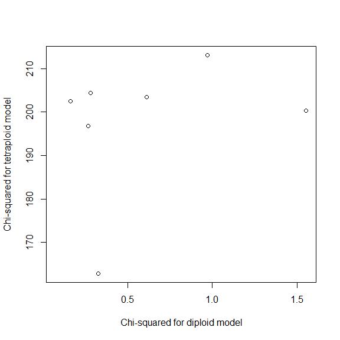

```r
plot(mydata$ploidyChiSq[1,], mydata$ploidyChiSq[2,],
     xlab = "Chi-squared for diploid model",
     ylab = "Chi-squared for tetraploid model")
```

For each allele, whichever model gives the lower Chi-squared value is the one with the best fit. In this case it looks like everything is diploid with fairly high confidence, in agreement with our $H_{ind}/H_E$ results.

Now we’ll examine the posterior genotype probabilities. These are still estimated separately for each ploidy.

```r
mydata$posteriorProb[[1,"2"]][,"Map1-089",1:8]
```

```
##      TP19030_0    TP19030_1  TP28986_0  TP28986_1   TP31810_0   TP31810_1    TP34939_0    TP34939_1
## 0 1.969255e-02 9.339240e-11 0.92839995 0.00000000 0.998431214 0.000000000 0.000000e+00 1.778922e-07
## 1 9.803075e-01 9.803075e-01 0.07160005 0.07160005 0.001568786 0.001568786 9.999998e-01 9.999998e-01
## 2 9.339240e-11 1.969255e-02 0.00000000 0.92839995 0.000000000 0.998431214 1.778922e-07 0.000000e+00
```

```r
mydata$posteriorProb[[2,"2"]][,"Map1-089",1:8]
```

```
##   TP19030_0 TP19030_1 TP28986_0 TP28986_1 TP31810_0 TP31810_1 TP34939_0 TP34939_1
## 0         0         0        NA        NA         0         0       NaN       NaN
## 1         0         0        NA        NA         1         0       NaN       NaN
## 2         1         1        NA        NA         0         0       NaN       NaN
## 3         0         0        NA        NA         0         1       NaN       NaN
## 4         0         0        NA        NA         0         0       NaN       NaN
```

### Results cleanup and export

Since we decided from the Chi-squared results that the markers were only segregating in a diploid manner, we can remove allotetraploidy from the dataset.

```r
mydata <- SubsetByPloidy(mydata, ploidies = list(2))
```

Typically in a mapping population, due to noisy data polyRAD will not be able to determine the segregation patterns of some markers, which end up having `NA` values for their prior and posterior probabilities. There may also be some cases where both parents were homozygous and as a result there is no segregation in an F1 population. In this example dataset, these issues are not present (as long as diploidy is assumed) because the markers were curated from a set that had already been filtered for mapping. Generally, however, you would want to find and remove such markers using `RemoveUngenotypedLoci`:

```r
mydata <- RemoveUngenotypedLoci(mydata)
```

We can export the results for use in downstream analysis. The function below weights possible ploidies for each allele based on the results in `mydata$ploidyChiSq`, and for each taxon outputs a continuous, numerical genotype that is the mean of all possible genotypes weighted by genotype posterior probabilities (*i.e.* the posterior mean genotype). By default, one allele per locus is discarded in order to avoid mathematical singularities in downstream analysis. The continuous genotypes also range from zero to one by default, which can be changed with the `minval` and `maxval` arguments.

```r
mywm <- GetWeightedMeanGenotypes(mydata)
round(mywm[c(276, 277, 1:5), 9:12], 3)
```

```
##                 TP53071_0 TP57018_0 TP110401_1 TP115159_0
## Kaskade-Justin        0.5       0.5        0.5        0.5
## Zebrinus-Justin       0.0       0.0        0.0        0.0
## Map1-001              0.5       0.5        0.0        0.0
## Map1-002              0.0       0.0        0.5        0.5
## Map1-003              0.0       0.0        0.0        0.5
## Map1-005              0.5       0.5        0.5        0.5
## Map1-008              0.0       0.0        0.5        0.0
```

Note that the parent posterior mean genotypes were estimated using gentoype likelihood only, ignoring the priors set for the progeny. In some places they may not match the progeny genotypes, indicating a likely error in parental genotype calling. We can see the parental genotypes that were used for estimating progeny priors using `$likelyGeno_donor` and `$likelyGeno_recurrent`.

```r
mydata$likelyGeno_donor[,1:8]
```

```
## TP19030_0 TP19030_1 TP28986_0 TP28986_1 TP31810_0 TP31810_1 TP34939_0 TP34939_1
##         1         1         1         1         0         2         1         1
```

```r
mydata$likelyGeno_recurrent[,1:8]
```

```
## TP19030_0 TP19030_1 TP28986_0 TP28986_1 TP31810_0 TP31810_1 TP34939_0 TP34939_1
##         1         1         0         2         1         1         2         0
```

## Estimating genotype probabilities in a diversity panel

Pipelines in polyRAD for processing a diversity panel (i.e. a germplasm collection, a set of samples collected in the wild, or a panel for genome-wide association analysis or genomic prediction) use iterative algorithms. Essentially, allele frequencies are re-estimated with each iteration until convergence is reached.

### Data import example with VCF

Here we’ll import a RAD-seq dataset from a large collection of wild and ornamental *Miscanthus* from Clark *et al.* (2014; [doi:10.1093/aob/mcu084](http://hdl.handle.net/10.1093/aob/mcu084)).

Since the data are in VCF format, we will need the Bioconductor package VariantAnnotation to load them. See https://bioconductor.org/packages/release/bioc/html/VariantAnnotation.html for installation instructions.

Again, with your own dataset you will not need to use `system.file` (see section on mapping populations).

```r
library(VariantAnnotation)

myVCF <- system.file("extdata", "Msi01genes.vcf", package = "polyRAD")
```

For your own VCF files, you will want to compress and index them before reading them. This has already been done for the file supplied with polyRAD, but here is how you would do it:

```r
mybg <- bgzip(myVCF)
indexTabix(mybg, format = "vcf")
```

This dataset is mostly diploid, but it contains a few haploid and triploid individuals. We’ll load a text file listing the ploidy of each individual.

```r
pldfile <- system.file("extdata", "Msi_ploidies.txt", package = "polyRAD")
msi_ploidies <- read.table(pldfile, sep = "\t", header = FALSE)
head(msi_ploidies)
```

```
##                   V1 V2
## 1              Akeno  2
## 2              blank  2
## 3 CANE9233-US47-0011  2
## 4      DC-2010-001-A  2
## 5      DC-2010-001-E  2
## 6              Gunma  2
```

```r
table(msi_ploidies$V2)
```

```
##
##   1   2   3
##   3 581   1
```

```r
pld_vect <- msi_ploidies$V2
names(pld_vect) <- msi_ploidies$V1
```

Now we can make our `RADdata` object. Because this is a small example dataset, we are setting `expectedLoci` and `expectedAlleles` to very low values; in a real dataset they should reflect how much data you are actually expecting. It is best to slightly overestimate the number of expected alleles and loci.

```r
mydata <- VCF2RADdata(myVCF, possiblePloidies = list(2, c(2,2)),
                      expectedLoci = 100, expectedAlleles = 500,
                      taxaPloidy = pld_vect)
```

```
## Reading file...
```

```
## Unpacking data from VCF...
```

```
## Filtering markers...
```

```
## Phasing 55 SNPs on chromosome 01
```

```
## Reading file...
```

```
## 24 loci imported.
```

```
## Building RADdata object...
```

```
## Merging rare haplotypes...
```

```
## 24 markers retained out of 24 originally.
```

```r
mydata
```

```
## ## RADdata object ##
## 585 taxa and 24 loci
## 422433 total reads
## Assumed sample cross-contamination rate of 0.001
##
## Possible ploidies:
## Autodiploid (2)
## Autotriploid (3)
## Autohaploid (1)
## Allotetraploid (2 2)
## Allohexaploid (3 3)
## Allodiploid (1 1)
```

### Quality control and parameter estimation

For natural populations and diversity panels, we can run `TestOverdispersion` before performing any genotype calling.

```r
overdispersionP <- TestOverdispersion(mydata, to_test = 8:14)
```

```
## Genotype estimates not found in object. Performing rough genotype estimation under HWE.
```

```
## Generating sampling permutations for allele depth.
```

```
## Optimal value is 10.
```

```r
sapply(overdispersionP[names(overdispersionP) != "optimal"],
       quantile, probs = c(0.01, 0.25, 0.5, 0.75, 0.99))
```

```
##              8          9        10        11         12         13          14
## 1%  0.03361521 0.02496243 0.0185622 0.0141304 0.01060993 0.00805366 0.006298907
## 25% 0.26936814 0.24868707 0.2290173 0.2086904 0.19289979 0.18050423 0.167115359
## 50% 0.53640477 0.51375557 0.4922544 0.4732410 0.46074857 0.44954064 0.435073179
## 75% 0.80687246 0.79642717 0.7870220 0.7785209 0.76967492 0.76067468 0.753409104
## 99% 1.00000000 1.00000000 1.0000000 1.0000000 1.00000000 1.00000000 1.000000000
```

In this case, ten looks like a good value. In the matrix of quantiles, we are looking for columns where the 25th percentile is about 0.25, the 50th percentile is about 0.5, etc. These libraries were made with 15 PCR cycles. If you used more PCR cycles you are likely to have a lower optimal value for the overdispersion parameter, or conversely if you used fewer PCR cycles you will probably have a higher value for the overdispersion parameter.

```r
my_ovdisp <- overdispersionP$optimal
```

Before we perform genotype calling, we can also test for Mendelian segregation at each marker using the $H_{ind}/H_E$ statistic.

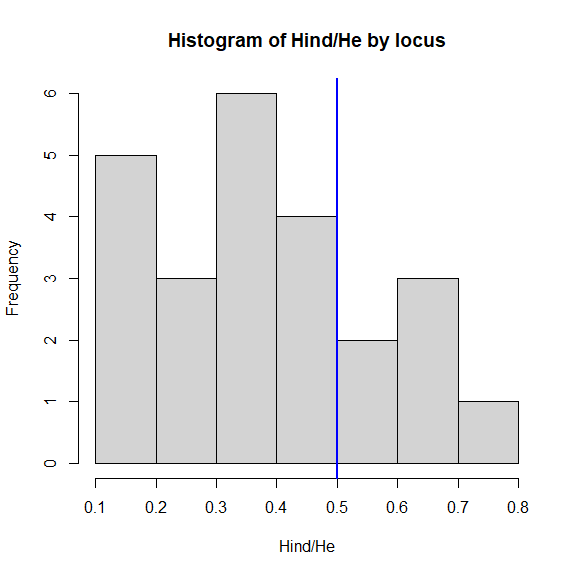

```r
myhindhe <- HindHe(mydata)
myhindheByLoc <- colMeans(myhindhe, na.rm = TRUE)
hist(myhindheByLoc, col = "lightgrey",
     xlab = "Hind/He", main = "Histogram of Hind/He by locus")
abline(v = 0.5, col = "blue", lwd = 2)
```

The peak below 0.5 indicates well-behaved diploid loci. For estimation of inbreeding, we’ll just want to look at markers with a minor allele frequency of at least 0.05, since lower minor allele frequencies tend to have a lot of bias in $H_{ind}/H_E$ dependent on sample size. We will also just look at the predominant ploidy (diploid in this case) to estimate inbreeding.

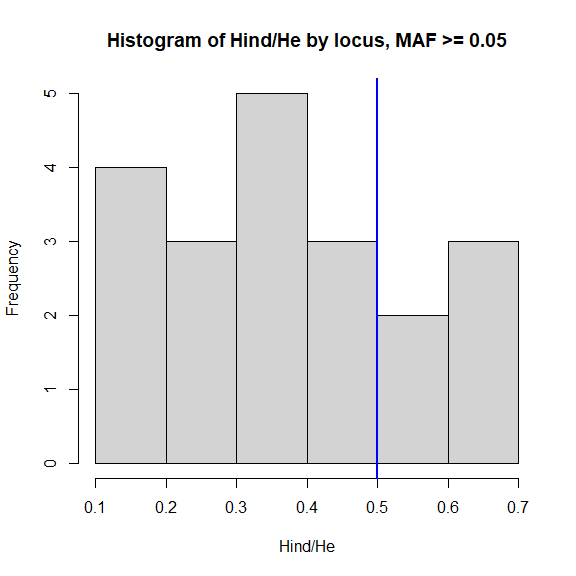

```r
mydata <- AddAlleleFreqHWE(mydata)
theseloci <- GetLoci(mydata)[mydata$alleles2loc[mydata$alleleFreq >= 0.05 & mydata$alleleFreq < 0.5]]
theseloci <- unique(theseloci)
myhindheByLoc2 <- colMeans(myhindhe[mydata$taxaPloidy == 2L, theseloci], na.rm = TRUE)
hist(myhindheByLoc2, col = "lightgrey",
     xlab = "Hind/He", main = "Histogram of Hind/He by locus, MAF >= 0.05")
abline(v = 0.5, col = "blue", lwd = 2)
```

In a typical dataset with more markers, you can get more resolution on the histogram (see the `breaks` argument of `hist`), but let’s say the peak is at 0.35. The graph below can be used to estimate inbreeding from $H_{ind}/H_E$ and overdispersion. For a diploid with overdispersion of 10 and $H_{ind}/H_E$ of 0.35, inbreeding is about 0.25. Note that the graph assumes a sequencing error rate of 0.001 and a minor allele frequency of at least 0.05.

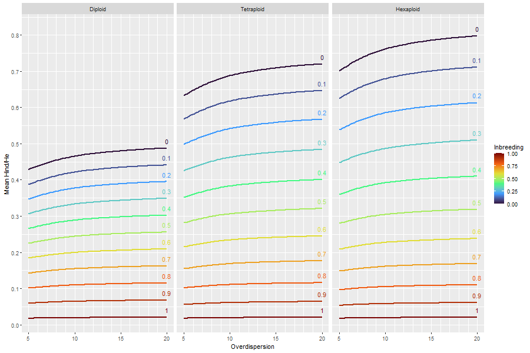

Estimation of inbreeding

There is also the `InbreedingFromHindHe` function for estimating inbreeding, but it is from an older version of polyRAD and does not account for overdispersion or sequencing error, leading to overestimates of inbreeding.

With overdispersion and inbreeding estimated, we can simulate what the $H_{ind}/H_E$ distribution might look like if the dataset consisted entirely of Mendelian diploid loci with no other technical issues. Here `reps` is set to 10 because of the size of the dataset and the need for a short run time, but in your own data is is probably best to leave it at the default. You do not need to use `set.seed` unless you are trying to reproduce this vignette exactly.

```r
set.seed(803)
ExpectedHindHe(mydata, inbreeding = 0.25, ploidy = 2, overdispersion = my_ovdisp,
               reps = 10, contamRate = 0.001, errorRate = 0.001)
```

```
## Simulating rep 1
```

```
## Completed 10 simulation reps.
```

```
## Mean Hind/He: 0.346
## Standard deviation: 0.0543
## 95% of observations are between 0.253 and 0.467
```

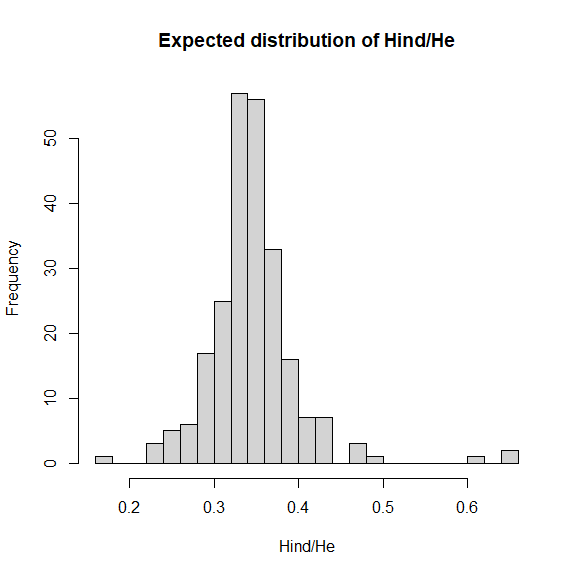

According to these results, good quality markers can be expected to have $H_{ind}/H_E$ values from about 0.24 to 0.48. Values lower than that indicate technical problems such as restriction cut site polymorphisms, causing overdispersion in the data that could reduce genotyping quality. Values higher than that indicate paralogy or higher ploidy than expected. Since we are allowing for allotetraploidy in our genotype calling, we’ll only remove markers where $H_{ind}/H_E$ is too low (although you may consider filtering differently in your own dataset).

```r
mean(myhindheByLoc < 0.24) # about 29% of markers would be removed
```

```
## [1] 0.2916667
```

```r
keeploci <- names(myhindheByLoc)[myhindheByLoc >= 0.24]
mydata <- SubsetByLocus(mydata, keeploci)
```

### Genotype calling

We can iteratively estimate genotype probabilities assuming Hardy-Weinberg equilibrium. The argument `tol` is set to a higher value than the default here in order to help the tutorial run more quickly. Since *Miscanthus* is highly outcrossing, we will leave the `selfing.rate` argument at its default of zero.

```r
mydataHWE <- IterateHWE(mydata, tol = 1e-3, overdispersion = 10)
```

Let’s take a look at allele frequencies:

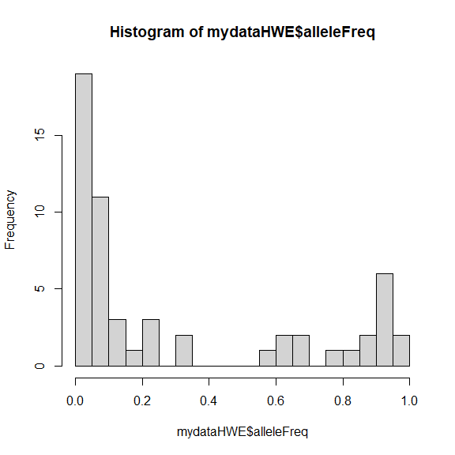

```r
hist(mydataHWE$alleleFreq, breaks = 20, col = "lightgrey")
```

We can do a different genotype probability estimation that models population structure and variation in allele frequencies among populations. We don’t need to specify populations, since principal components analysis is used to assess population structure assuming an isolation-by-distance model, with gradients of gene flow across many groups of individuals. This dataset includes a very broad sampling of *Miscanthus* across Asia, so it is very appropriate to model population structure in this case.

For this example, since random number generation is used internally by `IteratePopStruct` for probabalistic principal components analysis, I am setting a seed so that the vignette always renders in the same way.

```r
set.seed(3908)
mydataPopStruct <- IteratePopStruct(mydata, nPcsInit = 8, tol = 5e-03,
                                    overdispersion = 10)
```

Allele frequency estimates have changed slightly:

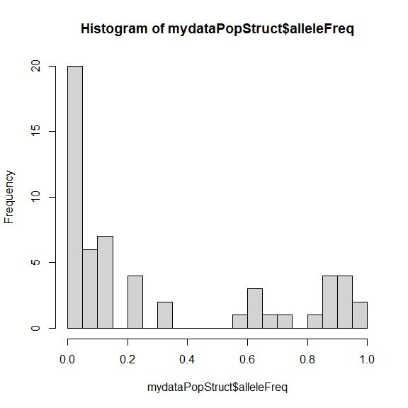

```r
hist(mydataPopStruct$alleleFreq, breaks = 20, col = "lightgrey")
```

Here’s some of the population structure that was used for modeling allele frequencies (fairly weak in this case because so few markers were used):

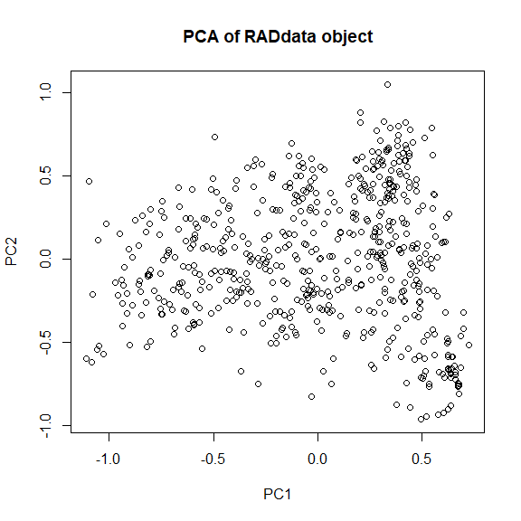

```r
plot(mydataPopStruct)
```

And here’s an example of allele frequency varying across the environment. Allele frequencies were estimated for each taxon, and are stored in the `$alleleFreqByTaxa` slot. In the plot below, color indicates estimated local allele frequency.

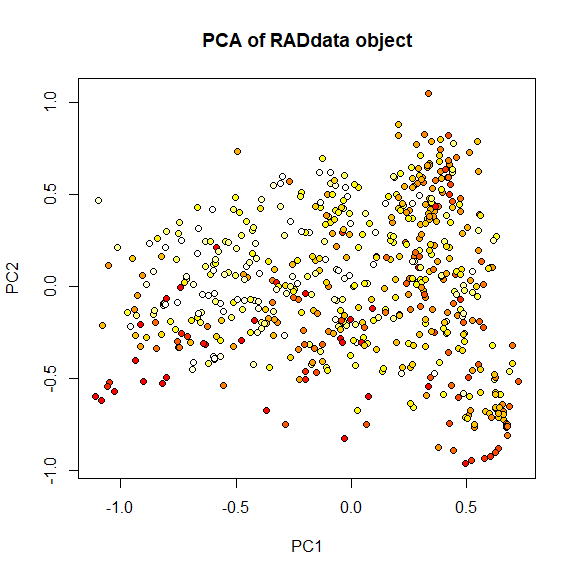

```r
myallele <- 1
freqcol <- heat.colors(101)[round(mydataPopStruct$alleleFreqByTaxa[,myallele] * 100) + 1]
plot(mydataPopStruct, pch = 21, bg = freqcol)
```

### Examining inheritance mode

Let’s examine the inheritance mode of the markers again now that we have run the pipeline.

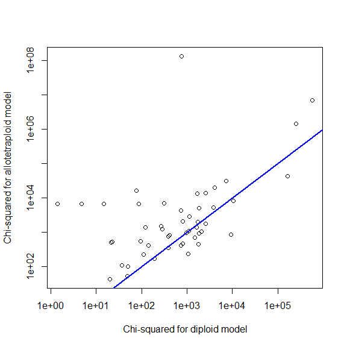

```r
plot(mydataPopStruct$ploidyChiSq[1,], mydataPopStruct$ploidyChiSq[2,],
     xlab = "Chi-squared for diploid model",
     ylab = "Chi-squared for allotetraploid model", log = "xy")
abline(a = 0, b = 1, col = "blue", lwd = 2)
```

It seems that some markers look allotetraploid, and others look diploid. We can see if this matches $H_{ind}/H_E$ results.

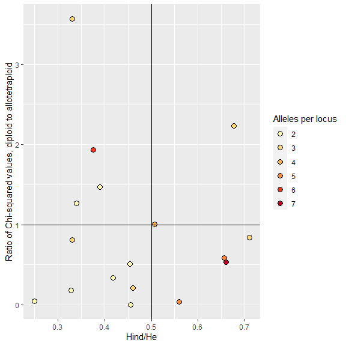

```r
myChiSqRat <- mydataPopStruct$ploidyChiSq[1,] / mydataPopStruct$ploidyChiSq[2,]
myChiSqRat <- tapply(myChiSqRat, mydataPopStruct$alleles2loc, mean)
allelesPerLoc <- as.vector(table(mydataPopStruct$alleles2loc))

library(ggplot2)
ggplot(mapping = aes(x = myhindheByLoc[GetLoci(mydata)], y = myChiSqRat, fill = as.factor(allelesPerLoc))) +
  geom_point(shape = 21, size = 3) +
  labs(x = "Hind/He", y = "Ratio of Chi-squared values, diploid to allotetraploid",
       fill = "Alleles per locus") +
  geom_hline(yintercept = 1) +
  geom_vline(xintercept = 0.5) +
  scale_fill_brewer(palette = "YlOrRd")
```

Markers that fall in (or near) the lower-left quadrent are probably well-behaved diploid markers, but others might represent merged paralogs.

As before, we can export the posterior mean genotypes for downstream analysis.

```r
wmgenoPopStruct <- GetWeightedMeanGenotypes(mydataPopStruct)
wmgenoPopStruct[1:10,1:5]
```

```
##                       S01_139820_TT S01_139820_CT S01_150928_GG S01_150928_AA S01_151004_A
## KMS207-8                0.884929543   0.114970457  2.867904e-08  9.992910e-08 7.415028e-03
## JM0051.003              0.007736915   0.279295342  3.370304e-07  1.031228e-06 7.481997e-02
## JM0034.001              0.125390846   0.317981638  1.268545e-04  6.107921e-07 2.588873e-02
## JM0220.001              0.220283676   0.171998526  1.061244e-07  3.562348e-07 1.000000e-04
## NC-2010-003-001         0.000100000   0.154894658  4.103560e-05  1.589559e-06 1.000000e-04
## JM0026.001              0.093776437   0.566301114  1.996941e-08  2.563725e-06 1.000000e-04
## JM0026.002              0.162077586   0.163232974  2.925276e-03  3.066340e-06 7.940355e-02
## PI294605-US64-0007-01   0.006523966   0.008399963  1.963375e-06  6.720166e-09 6.177545e-02
## JM0058.001              0.671449424   0.293410060  2.940711e-04  1.775268e-07 6.135116e-03
## UI10-00086-Silberfeil   0.000100000   0.127364065  2.360426e-09  8.333395e-09 3.272857e-05
```

### Other genotype calling functions

If you expect that your species has high linkage disequilibrium, the functions `IterateHWE_LD` and `IteratePopStructLD` behave like `IterateHWE` and `IteratePopStruct`, respectively, but also update priors based on genotypes at linked loci.

## $H_{ind}/H_E$ for filtering markers and individuals

GBS/RAD data are inherently messy. Some markers may behave in a non-Mendelian fashion due to misalignments, amplification bias, presence-absence variation, or other issues. In addition to filtering out problematic markers, you may also want to confirm that all individuals in the dataset are well-behaved.

Below we’ll work with a dataset from *Miscanthus sacchariflorus*, including 635 individuals and 1000 loci ([Clark et al. 2018](https://doi.org/10.1093/aob/mcy161)). The `RADdata` object is not provided here due to size, but the following objects were created from it:

```r
myHindHe <- HindHe(mydata)
TotDepthT <- rowSums(mydata$locDepth)
```

We will load these:

```r
print(load(system.file("extdata", "MsaHindHe0.RData", package = "polyRAD")))
```

```
## [1] "myHindHe"  "ploidies"  "TotDepthT"
```

This additionally provides a vector called `ploidies` indicating the ploidy of each individual, determined primarily by flow cytometry. `myHindHe` is a matrix with one value per individual*locus, and `TotDepthT` is a vector showing the total read depth at each locus.

To investigate individuals, we can take the row means of the matrix:

```r
myHindHeByInd <- rowMeans(myHindHe, na.rm = TRUE)
```

Then we can plot these versus depth for each ploidy.

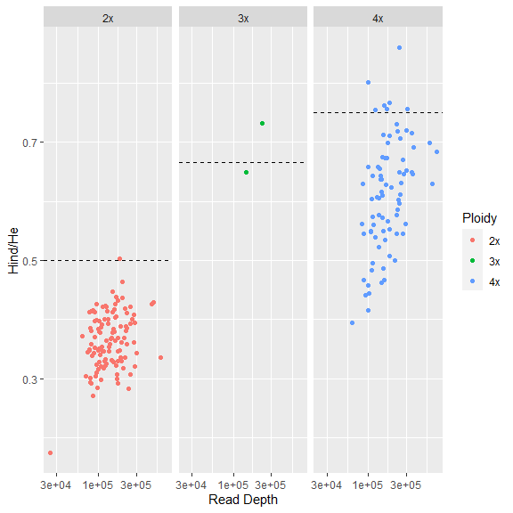

```r
ggplot(data.frame(Depth = TotDepthT, HindHe = myHindHeByInd,
                  Ploidy = ploidies),
  mapping = aes(x = Depth, y = HindHe, color = Ploidy)) +
  geom_point() +
  scale_x_log10() +
  facet_wrap(~ Ploidy) +
  geom_hline(data = data.frame(Ploidy = c("2x", "3x", "4x"),
                               ExpHindHe = c(1/2, 2/3, 3/4)),
             mapping = aes(yintercept = ExpHindHe), lty = 2) +
  labs(x = "Read Depth", y = "Hind/He", color = "Ploidy")
```

Dashed lines indicate the expected value under Hardy-Weinberg Equilibrium. This is $\frac{ploidy - 1}{ploidy}$, *e.g.* 0.5 for diploids and 0.75 for tetraploids. Since there is some population structure, most individuals show a lower value. However, some interspecific hybrids have values higher than expected. We can also see that it is fairly easy to distinguish diploids and tetraploids. This method is not a replacement for flow cytometry, but can complement it if some minority of samples in the dataset have unknown ploidy.

Let’s divide the $H_{ind}/H_E$ results into those for diploids vs. tetraploids.

```r
myHindHe2x <- myHindHe[ploidies == "2x",]
myHindHe4x <- myHindHe[ploidies == "4x",]
```

Now we can look a the distribution of values across markers.

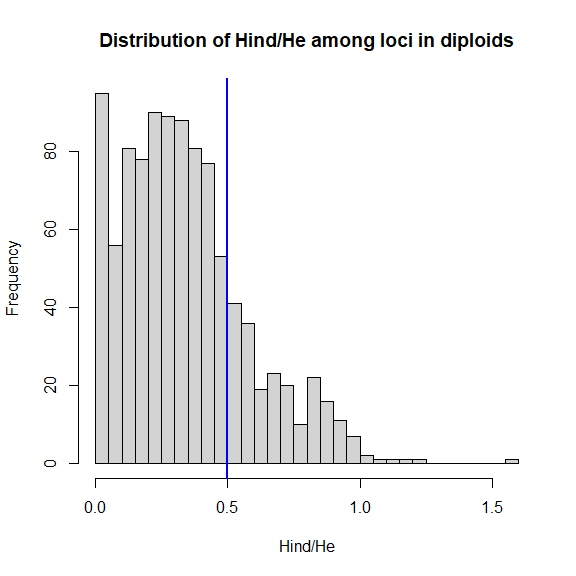

```r
myHindHeByLoc2x <- colMeans(myHindHe2x, na.rm = TRUE)
hist(myHindHeByLoc2x, breaks = 50, xlab = "Hind/He",
     main = "Distribution of Hind/He among loci in diploids",
     col = "lightgrey")
abline(v = 0.5, col = "blue", lwd = 2)
```

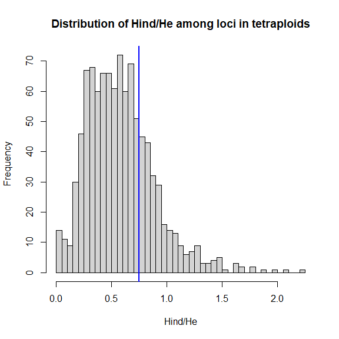

```r
myHindHeByLoc4x <- colMeans(myHindHe4x, na.rm = TRUE)
hist(myHindHeByLoc4x, breaks = 50, xlab = "Hind/He",
     main = "Distribution of Hind/He among loci in tetraploids",
     col = "lightgrey")
abline(v = 0.75, col = "blue", lwd = 2)
```

Most loci look good, but those to the right of the blue line should probably be filtered from the dataset.

```r
goodLoci <- colnames(myHindHe)[myHindHeByLoc2x < 0.5 & myHindHeByLoc4x < 0.75]
length(goodLoci) # 611 out of 1000 markers retained
```

```
## [1] 611
```

```r
head(goodLoci)
```

```
## [1] "S05_132813"  "S05_266733"  "S05_606899"  "S05_754184"  "S05_764224"  "S05_1643871"
```

The `goodLoci` vector that we created here could then be used by `SubsetByLocus` to filter the dataset. Remember that you would also want to set the `taxaPloidy` slot to indicate the ploidy of each individual. The `ExpectedHindHe` function can also help with determining a good cutoff for filtering markers.

## Considerations for RAM and processing time

`RADdata` objects contain large matrices and arrays for storing read depth and the parameters that are estimated by the pipeline functions, and as a result require a lot of RAM (computer memory) in comparison to the posterior mean genotypes that are exported. A `RADdata` object that has just been imported will take up less RAM than one that has been processed by a pipeline function. `RADdata` objects will also take up more RAM (and take longer for pipeline functions to process) if they have more possible ploidies and/or higher ploidies.

If you have hundreds of thousands, or possibly even tens of thousands, of markers in your dataset, it may be too large to process as one object on a typical computer. In that case, I recommend using the `SplitByChromosome` function immediately after import. This function will create separate `RADdata` objects by chromosomes or groups of chromosomes, and will save those objects to separate R workspace (.RData) files on your hard drive. You can then run a loop to re-import those objects one at a time, process each one with a pipeline function, and export posterior mean geneotypes (or any other parameters you wish to keep) to a file or a smaller R object. If you have access to a high performance computing cluster, you may instead wish to process individual chromosomes as parallel jobs.

If you don’t have alignment positions for your markers, or if you want to divide them up some other way than by chromosome, see `SubsetByLocus`. If you are importing from VCF but don’t want to import the whole genome at once, see the examples on the help page for `VCF2RADdata` for how to import just a particular genomic region.

You might use `SubsetByLocus` and select a random subset of ~1000 loci to use with `TestOverdispersion` for estimating the overdispersion parameter.

If you are using one of the iterative pipelines, it is possible to set the `tol` argument higher in order to reduce processing time at the expense of accuracy.

After you have run a pipeline, if you want to keep the `RADdata` object but discard any components that are not needed for genotype export, you can use the `StripDown` function.

Below is an example script showing how I processed a real dataset with hundreds of thousands of SNPs. Note that the (very large) VCF files are not included with the polyRAD installation.

```r
library(polyRAD)
library(VariantAnnotation)

# Two files produced by the TASSEL-GBSv2 pipeline using two different
# enzyme systems.
NsiI_file <- "170705Msi_NsiI_genotypes.vcf.bgz"
PstI_file <- "170608Msi_PstI_genotypes.vcf.bgz"

# The vector allSam was defined outside of this script, and contains the
# names of all samples that I wanted to import.  Below I find sample names
# within the VCF files that match those samples.
NsiI_sam <- allSam[allSam %in% samples(scanVcfHeader(NsiI_file))]
PstI_sam <- allSam[allSam %in% samples(scanVcfHeader(PstI_file))]

# Import two RADdata objects, assuming diploidy.  A large yield size was
# used due to the computer having 64 Gb RAM; on a typical laptop you
# would probably want to keep the default of 5000.
PstI_RAD <- VCF2RADdata(PstI_file, samples = PstI_sam, yieldSize = 5e4,
                        expectedAlleles = 1e6, expectedLoci = 2e5)
NsiI_RAD <- VCF2RADdata(NsiI_file, samples = NsiI_sam, yieldSize = 5e4,
                        expectedAlleles = 1e6, expectedLoci = 2e5)

# remove any loci duplicated across the two sets
nLoci(PstI_RAD)    # 116757
nLoci(NsiI_RAD)    # 187434
nAlleles(PstI_RAD) # 478210
nAlleles(NsiI_RAD) # 952511
NsiI_keeploci <- which(!GetLoci(NsiI_RAD) %in% GetLoci(PstI_RAD))
cat(nLoci(NsiI_RAD) - length(NsiI_keeploci),
    file = "180522Num_duplicate_loci.txt") #992 duplicate
NsiI_RAD <- SubsetByLocus(NsiI_RAD, NsiI_keeploci)

# combine allele depth into one matrix
PstI_depth <- PstI_RAD$alleleDepth
NsiI_depth <- NsiI_RAD$alleleDepth
total_depth <- matrix(0L, nrow = length(allSam),
                      ncol = ncol(PstI_depth) + ncol(NsiI_depth),
                      dimnames = list(allSam,
                                      c(colnames(PstI_depth),
                                        colnames(NsiI_depth))))
total_depth[,colnames(PstI_depth)] <- PstI_depth[allSam,]
total_depth[rownames(NsiI_depth),colnames(NsiI_depth)] <- NsiI_depth

# combine other slots
total_alleles2loc <- c(PstI_RAD$alleles2loc,
                       NsiI_RAD$alleles2loc + nLoci(PstI_RAD))
total_locTable <- rbind(PstI_RAD$locTable, NsiI_RAD$locTable)
total_alleleNucleotides <- c(PstI_RAD$alleleNucleotides,
                             NsiI_RAD$alleleNucleotides)

# build new RADdata object and save
total_RAD <- RADdata(total_depth, total_alleles2loc, total_locTable,
                     list(2L), 0.001, total_alleleNucleotides)
#save(total_RAD, file = "180524_RADdata_NsiIPstI.RData")

# Make groups representing pairs of chromosomes, and one group for all
# non-assembled scaffolds.
splitlist <- list(c("^01$", "^02$"),
                  c("^03$", "^04$"),
                  c("^05$", "^06$"),
                  c("^07$", "^08$"),
                  c("^09$", "^10$"),
                  c("^11$", "^12$"),
                  c("^13$", "^14$", "^15$"),
                  c("^16$", "^17$"),
                  c("^18$", "^194"), "^SCAFFOLD")
# split by chromosome and save seperate objects
SplitByChromosome(total_RAD, chromlist = splitlist,
                  chromlist.use.regex = TRUE, fileprefix = "180524splitRAD")

# files with RADdata objects
splitfiles <- grep("^180524splitRAD", list.files("."), value = TRUE)

# list to hold markers formatted for GAPIT/FarmCPU
GAPITlist <- list()
length(GAPITlist) <- length(splitfiles)

# loop through RADdata objects
for(i in 1:length(splitfiles)){
  load(splitfiles[i])
  splitRADdata <- IteratePopStructLD(splitRADdata)
  GAPITlist[[i]] <- ExportGAPIT(splitRADdata)
}
#save(GAPITlist, file = "180524GAPITlist.RData")

# put together into one dataset for FarmCPU
GM.all <- rbind(GAPITlist[[1]]$GM, GAPITlist[[2]]$GM, GAPITlist[[3]]$GM,
                GAPITlist[[4]]$GM, GAPITlist[[5]]$GM, GAPITlist[[6]]$GM,
                GAPITlist[[7]]$GM, GAPITlist[[8]]$GM,
                GAPITlist[[9]]$GM, GAPITlist[[10]]$GM)
GD.all <- cbind(GAPITlist[[1]]$GD, GAPITlist[[2]]$GD[,-1],
                GAPITlist[[3]]$GD[,-1], GAPITlist[[4]]$GD[,-1],
                GAPITlist[[5]]$GD[,-1], GAPITlist[[6]]$GD[,-1],
                GAPITlist[[7]]$GD[,-1], GAPITlist[[8]]$GD[,-1],
                GAPITlist[[9]]$GD[,-1], GAPITlist[[10]]$GD[,-1])
#save(GD.all, GM.all, file = "180525GM_GD_all_polyRAD.RData") # 1076888 markers
```

## Citing polyRAD

Clark LV, Lipka AE, and Sacks EJ (2019) polyRAD: Genotype calling with uncertainty from sequencing data in polyploids and diploids. *G3* 9(3):663–673, [doi:10.1534/g3.118.200913](https://doi.org/10.1534/g3.118.200913).

To cite the $H_{ind}/H_E$ statistic:

Clark LV, Mays W, Lipka AE, and Sacks EJ (2022) A population-level statistic for assessing Mendelian behavior of genotyping-by-sequencing data from highly duplicated genomes. *BMC Bioinformatics* 23: 101, [doi:10.1186/s12859-022-04635-9](https://doi.org/10.1186/s12859-022-04635-9).